# DATA 152 HW7 - TYLER BONTRAGER

Due April 12, 2023 @ 11:59pm

** CHANGE YOUR NAME IN THE HEADER and then complete the following questions. **  
Failure to do so will result in a deduction of 5 points.

Subquestions are worth 5 points each.

## QUESTION 1

In an investigation of environmental causes of disease, data were collected on the annual mortality rate (deaths per 100,000) for males in the 61 large towns in England and Wales. In addition, the water hardness was recorded as the calcium concentration (ppm) in the drinking water. The dataset also notes, for each town, whether it was south or north of Derby. Is there a significant difference in mortality rates in the two regions?

### 1A

Read in the `Hard_water.txt` dataset and name it `water`.

```r
getwd()
```

```
## [1] "C:/Users/epicm/Documents/School/20222023/ISWR/hw/HW7"
```

```r
water = read_delim("Hard_water.txt",delim="\t")
head(water)
```

```
## # A tibble: 6 × 3
##   Mortality Calcium Region
##       <dbl>   <dbl> <chr>
## 1      1702      44 South
## 2      1309      59 South
## 3      1259     133 South
## 4      1427      27 North
## 5      1724       6 North
## 6      1175     107 South
```

### 1B

What are your null and alternative hypotheses?

**ANSWER:** Null: there is no significant difference in mortality rates between north and south. Alt: there is a difference in mortality rates between north and south.

### 1C

Create 2 histograms of the mortality rates–one for each region (south or north of Derby).

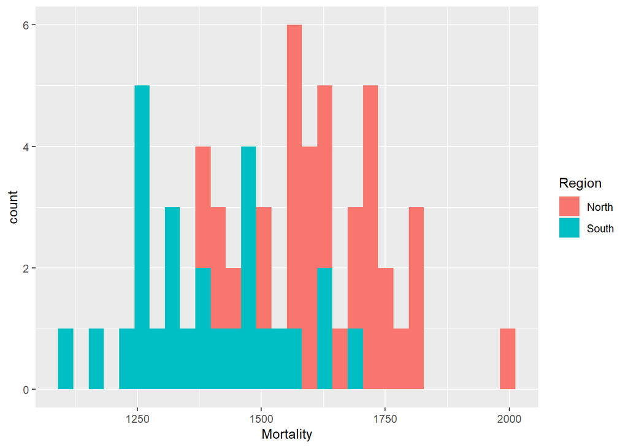

```r
ggplot(water) +
  geom_histogram(aes(x=Mortality, fill=Region))
```

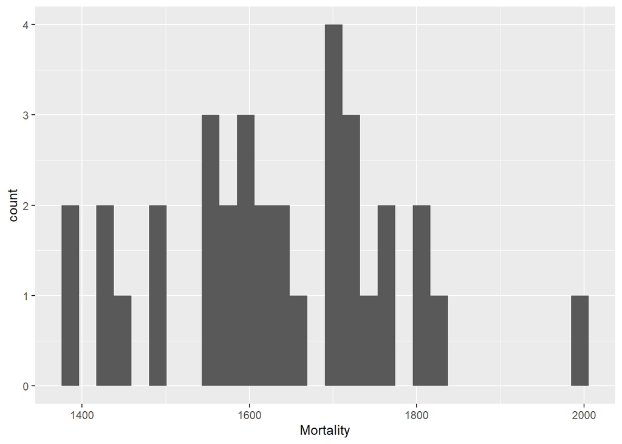

```r
north = water %>%
  filter(Region=="North")
south = water %>%
  filter(Region=="South")

ggplot(north)+
  geom_histogram(aes(x=Mortality))
```

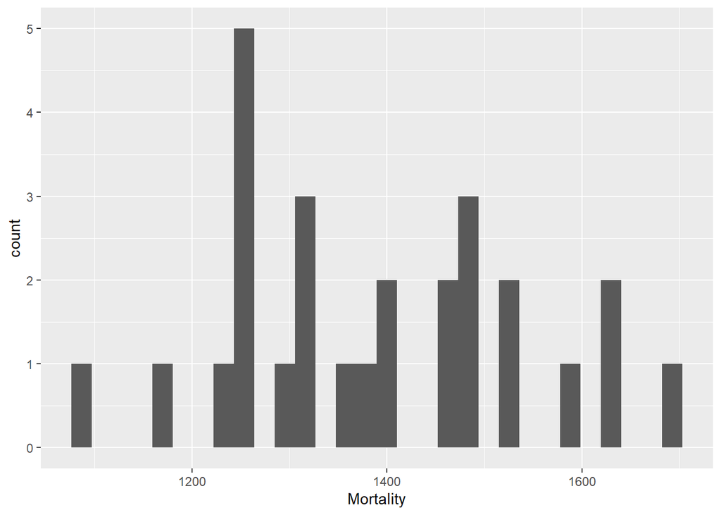

```r
ggplot(south)+
  geom_histogram(aes(x=Mortality))
```

### 1D

Are the assumptions for a 2-sample t-test satisfied? Justify your answer.

**ANSWER:** Yes. The data seems normally distributed, each record is independent (can’t be both north and south of Derby), and the sample is representative.

### 1E

Carry out a 2-sample t-test. Make sure your output is printed in the rendered HTML document.

```r
t.test(x=water$Region=="North",y=water$Region=="South",alternative="two.sided")
```

```
##
##  Welch Two Sample t-test
##
## data:  water$Region == "North" and water$Region == "South"
## t = 1.2654, df = 120, p-value = 0.2082
## alternative hypothesis: true difference in means is not equal to 0
## 95 percent confidence interval:
##  -0.0647940  0.2943022
## sample estimates:
## mean of x mean of y
##  0.557377  0.442623
```

### 1F

What is your conclusion in context of the original problem?

## QUESTION 2

### 2A

Read in mlb2022.txt (comma delimited) and complete the following:

### 2B

Create side-by-side boxplots that show the # of homeruns (HR) vs. position.

```r
mlb = read_csv("mlb2022.txt")
head(mlb)
```

```
## # A tibble: 6 × 19
##   PLAYER POSIT…¹ TEAM      G    AB     R     H DOUBLES TRIPLES    HR   RBI    BB
##   <chr>  <chr>   <chr> <dbl> <dbl> <dbl> <dbl>   <dbl>   <dbl> <dbl> <dbl> <dbl>
## 1 Aaron… CF      NYY     157   570   133   177      28       0    62   131   111
## 2 Yorda… DH      HOU     135   470    95   144      29       2    37    97    78
## 3 PaulG… 1B      STL     151   561   106   178      41       0    35   115    79
## 4 JoseA… 2B      HOU     141   527   103   158      39       0    28    57    66
## 5 Fredd… 1B      LAD     159   612   117   199      47       2    21   100    84
## 6 Manny… 3B      SD      150   578   100   172      37       1    32   102    63
## # … with 7 more variables: SO <dbl>, SB <dbl>, CS <dbl>, AVG <dbl>, OBP <dbl>,
## #   SLG <dbl>, OPS <dbl>, and abbreviated variable name ¹POSITION
```

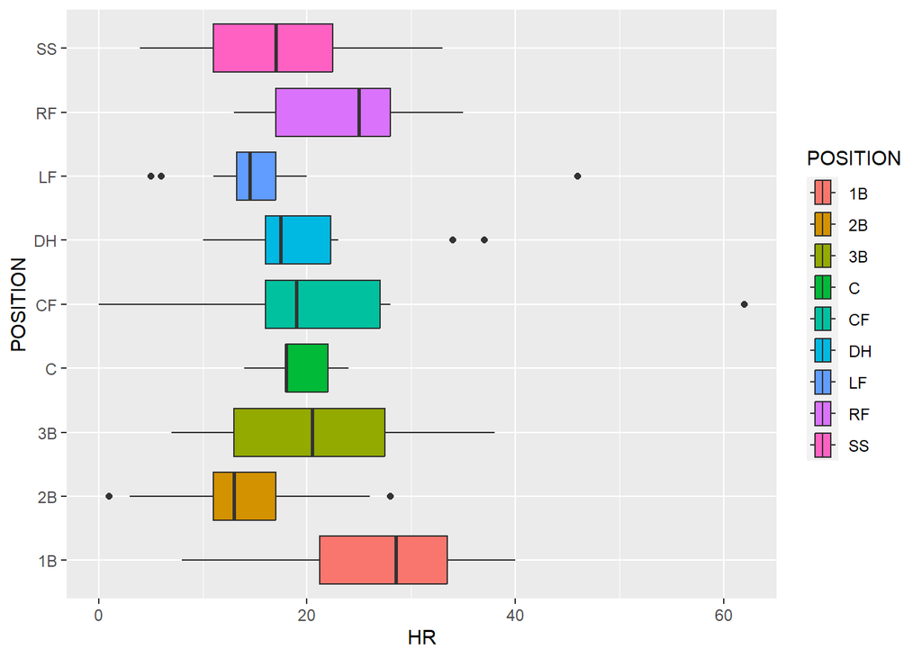

```r
ggplot(mlb, aes(x=HR,y=POSITION,fill=POSITION)) +
  geom_boxplot()
```

### 2C

QUESTION OF INTEREST: Is the mean # of homeruns hit statistically different among the positions?

What are your null and alternate hypotheses?

**ANSWER:** N: The true mean of number of homeruns hit is not statistically different among positions. A: The true mean of number of homeruns hit is statistically different among positions.

### 2D

Filter your data to only include players who have played a minimum of 125 games. Name this dataset `baseball`.

```r
baseball = mlb %>%
  filter(G>=125)
baseball
```

```
## # A tibble: 126 × 19
##    PLAYER      POSIT…¹ TEAM      G    AB     R     H DOUBLES TRIPLES    HR   RBI
##    <chr>       <chr>   <chr> <dbl> <dbl> <dbl> <dbl>   <dbl>   <dbl> <dbl> <dbl>
##  1 AaronJudge  CF      NYY     157   570   133   177      28       0    62   131
##  2 YordanAlva… DH      HOU     135   470    95   144      29       2    37    97
##  3 PaulGoldsc… 1B      STL     151   561   106   178      41       0    35   115
##  4 JoseAltuve  2B      HOU     141   527   103   158      39       0    28    57
##  5 FreddieFre… 1B      LAD     159   612   117   199      47       2    21   100
##  6 MannyMacha… 3B      SD      150   578   100   172      37       1    32   102
##  7 NolanArena… 3B      STL     148   557    73   163      42       1    30   103
##  8 RafaelDeve… 3B      BOS     141   555    84   164      42       1    27    88
##  9 AustinRiley 3B      ATL     159   615    90   168      39       2    38    93
## 10 ShoheiOhta… DH      LAA     157   586    90   160      30       6    34    95
## # … with 116 more rows, 8 more variables: BB <dbl>, SO <dbl>, SB <dbl>,
## #   CS <dbl>, AVG <dbl>, OBP <dbl>, SLG <dbl>, OPS <dbl>, and abbreviated
## #   variable name ¹POSITION
```

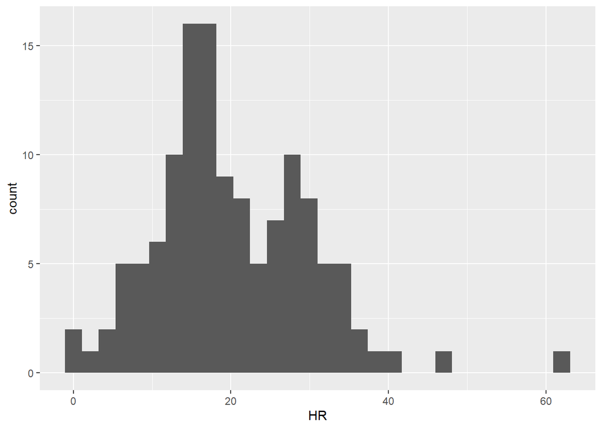

```r
baseball %>%
  ggplot(aes(x=HR)) +
  geom_histogram()
```

### 2E

Are the assumptions of the Tukey HSD test satisfied? Justify your answer.

**ANSWER:** Yes 1) normally distributed 2) independent records 3) representative sample

### 2F

Conduct a TukeyHSD test on the `baseball` dataset to answer the question of interest. Sort the p-values from least to greatest.

```r
library(car)
mod = aov(HR~POSITION,data=baseball)
tukee = TukeyHSD(mod,conf.level=0.95)
tukee2 = as_tibble(tukee$POSITION)
tukee2 %>% arrange(`p adj`)
```

```
## # A tibble: 36 × 4
##      diff      lwr    upr `p adj`
##     <dbl>    <dbl>  <dbl>   <dbl>
##  1 -12.3  -22.0    -2.52  0.00375
##  2 -10.4  -20.7    -0.157 0.0437
##  3  10.5   -0.0858 21.2   0.0537
##  4  -9.10 -18.5     0.265 0.0638
##  5   8.70  -2.40   19.8   0.254
##  6   9.10  -2.78   21.0   0.283
##  7  -7.37 -17.6     2.90  0.370
##  8   6.46  -3.04   16.0   0.446
##  9  -5.8  -15.2     3.56  0.576
## 10   6.96  -4.52   18.5   0.604
## # … with 26 more rows
```

### 2G

What are your results (in context of the original question)?

## QUESTION 3

A commonly discussed phenomenon around attending college is gaining the “freshman 15”–i.e. the extra 15 pounds that so often accompany the first year at college. Cornell Professor of Nutrition David Letisky did a study on this phenomenon. He recruited students from 2 large sections of an intro health course. Although they were volunteers, they appeared to match the rest of the first year class in terms of demographic variables such as sex and ethnicity. The students were weighed during the first week of the semester and again 12 weeks later.

The resulting data is in the “Freshman_15.txt” dataset.

### 3A

Read in the dataset and name it “ds”.

```r
ds = read_delim("Freshman_15.txt",delim="\t")
head(ds)
```

```
## # A tibble: 6 × 3
##   Subject Initial.Weight Terminal.Weight
##     <dbl>          <dbl>           <dbl>
## 1       1            171             168
## 2       2            110             111
## 3       3            134             136
## 4       4            115             119
## 5       5            150             155
## 6       6            104             106
```

### 3B

What are your null and alternative hypotheses?

**ANSWER:** N: There is no statistical difference between the weights from first week to week 12 that supports the “freshman 15” idea; the mean difference in weights is zero. A: The true mean of the difference in weights is greater than zero (in fact, 15 is the claim).

### 3C

Create a column that calculates the terminal weight - initial weight. Name this column “diff”.

```r
ds = ds %>%
  mutate(diff=Terminal.Weight-Initial.Weight)
ds
```

```
## # A tibble: 68 × 4
##    Subject Initial.Weight Terminal.Weight  diff
##      <dbl>          <dbl>           <dbl> <dbl>
##  1       1            171             168    -3
##  2       2            110             111     1
##  3       3            134             136     2
##  4       4            115             119     4
##  5       5            150             155     5
##  6       6            104             106     2
##  7       7            142             148     6
##  8       8            120             124     4
##  9       9            144             148     4
## 10      10            156             154    -2
## # … with 58 more rows
```

### 3D

Create a histogram of the difference column.

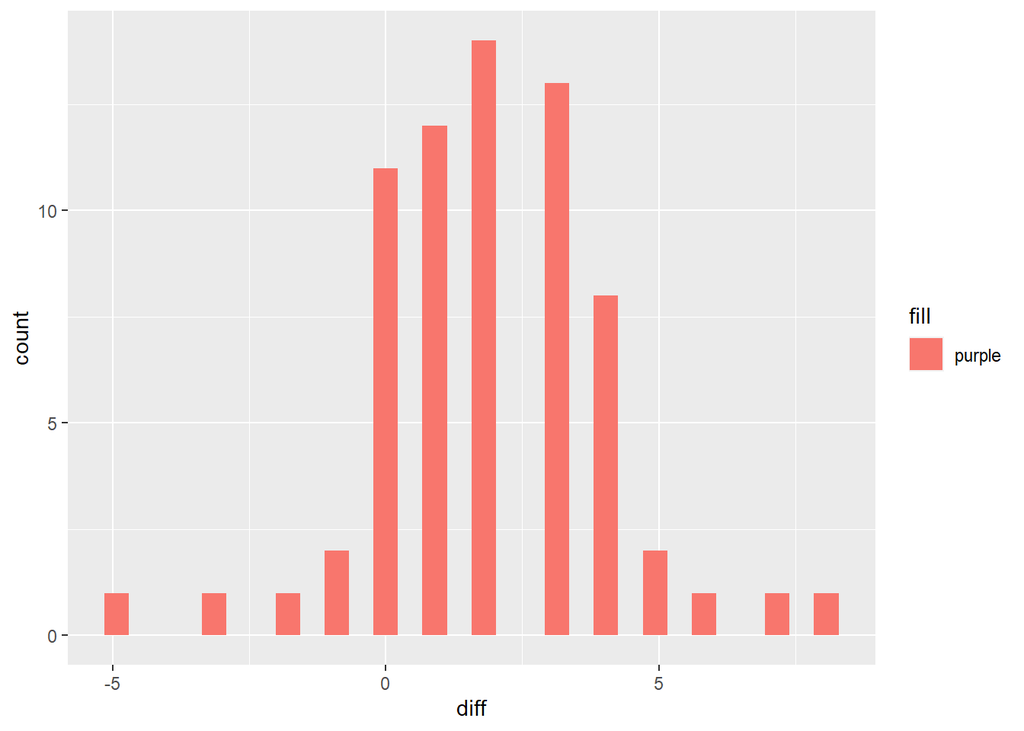

```r
ds %>%
  ggplot(aes(x=diff,fill="purple")) +
  geom_histogram()
```

### 3E

Are the assumptions of a paired t-test satisfied? Justify your answer.

**ANSWER:** 1) normally distributed 2) independent records 3) maybe representative sample. These are just students from some health classes. Dubious, but representative enough for an exercise.

### 3F

Carry out a paired t-test using t.test. Make sure the output of the test is shown in your rendered HTML.

```r
t.test(x=ds$Initial.Weight,y=ds$Terminal.Weight,paired=T,alternative="greater")
```

```
##
##  Paired t-test
##
## data:  ds$Initial.Weight and ds$Terminal.Weight
## t = -7.4074, df = 67, p-value = 1
## alternative hypothesis: true mean difference is greater than 0
## 95 percent confidence interval:
##  -2.342232       Inf
## sample estimates:
## mean difference
##       -1.911765
```

### 3G

Based on the hypothesis test results (and subsequent p-value), is the “Freshman 15” a myth?

**ANSWER:** Yes. It seems so.

*INSTRUCTIONS TO SUBMIT* Knit this into an html document and submit BOTH the Rmd and the html file in WISE. Name both files using this naming convention: LASTNAME_FIRSTNAME_DATA152_HW7.Rmd (or html). For example, Dr. Gore’s submissions would be named GORE_KRISTEN_DATA152_HW7.Rmd and GORE_KRISTEN_DATA152_HW7.html. Failure to follow these instructions will result in a 10-point deduction.